# Growing populations, Expanding challenges

Understand the impact of population growth on global development.

Author

Marie Kolibas

Published

April 27, 2025

From 2.1% in 1960 to just 0.9% in 2023, the world’s population growth rate has more than halved in 6 decades.

In the **collective imagination, strong demographic growth** is often seen as a **driver of economic dynamism**. But is this always the case? A fast-growing population can also **put pressure on infrastructures, natural resources and public services, creating development inequalities.**

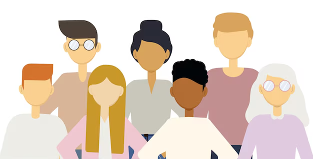

# A global slowdown trend

While the **global growth rate is steadily declining**, this slowdown is **not uniform** from one continent to the next, as we shall see.

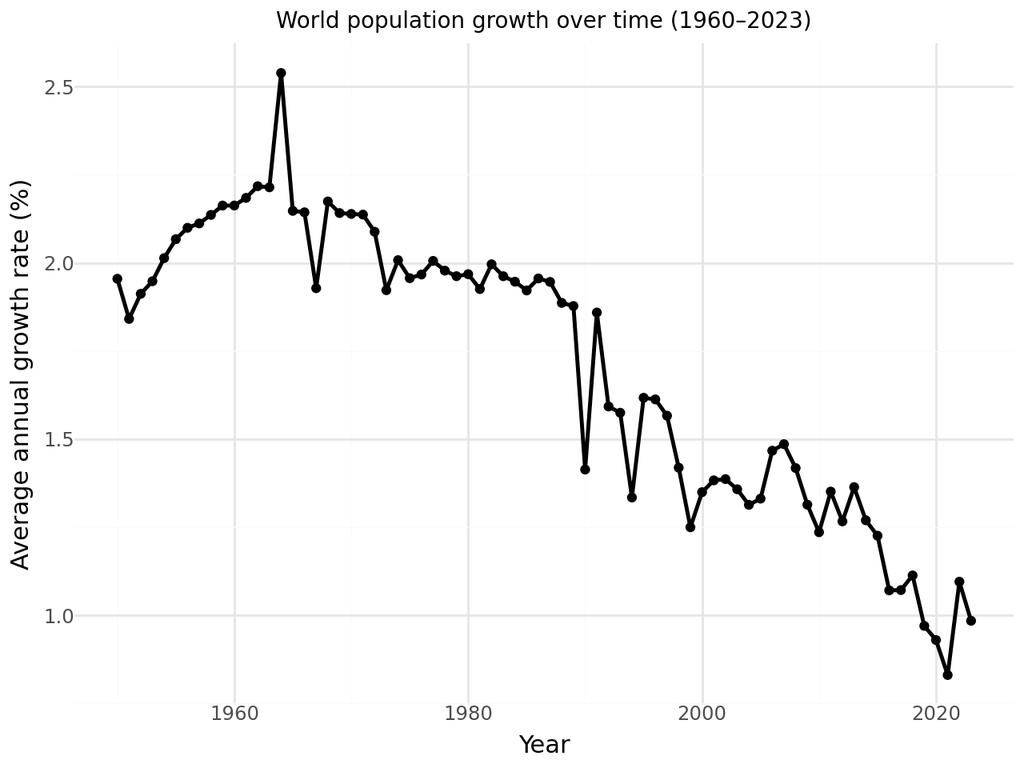

The bar chart shows how global growth dynamics have gradually shifted towards a handful of regions, highlighting growing regional disparities in population trends.

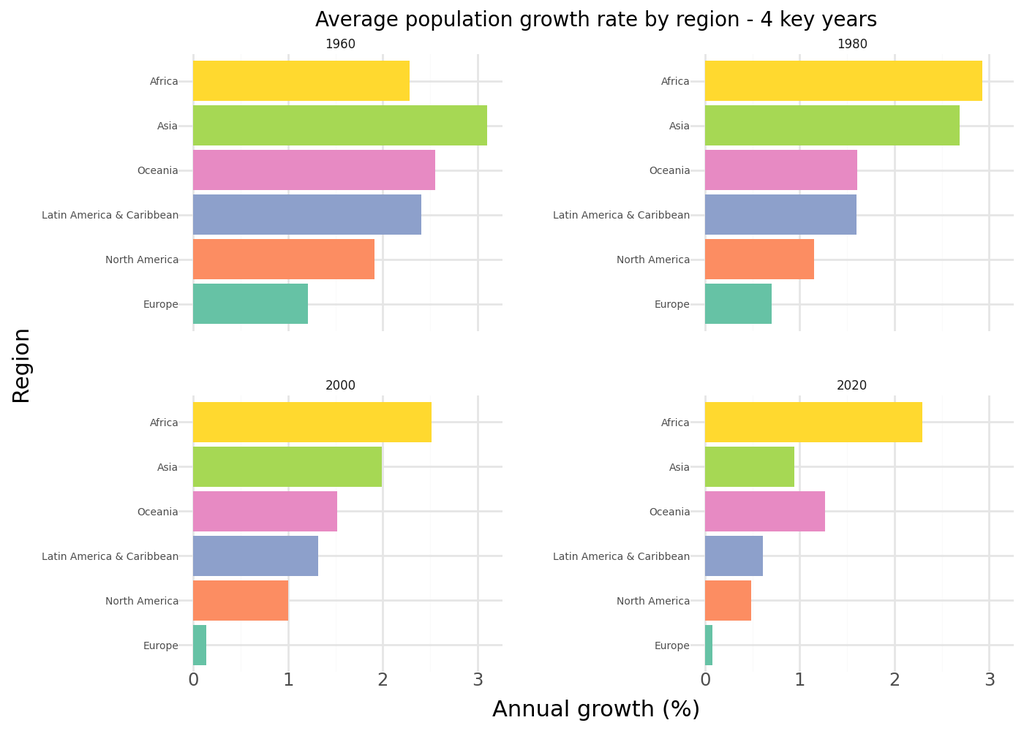

# Where is population increasing the most?

A demographic divide is emerging: While many **developing countries continue to grow rapidly**, most **developed nations are slowing down or even regressing.**

Countries such as **Russia and China** are now showing **negative growth**, **marking a turning point in global demographic trends.**

This growing imbalance raises important questions about the future: **How will societies adapt to aging populations, changing workforces and uneven demographic pressures?**

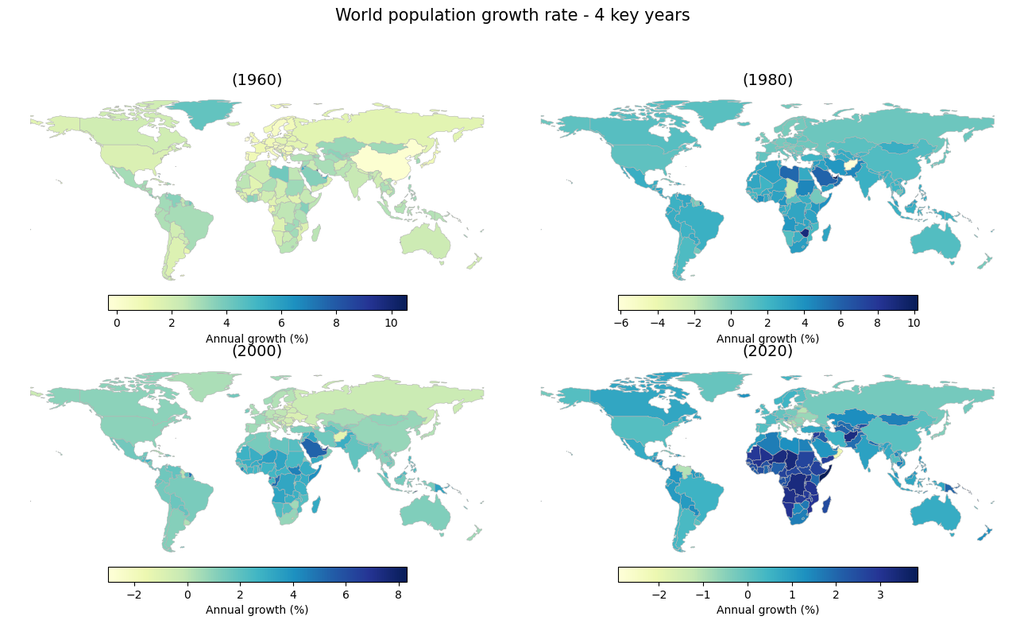

# Healthier nations, slower growth: A global demographic shift

**This suggests a global shift:** Better access to healthcare is no longer just a matter of survival, it’s associated with **lower fertility, better planning and longer life.**

**These two dimensions combined highlight a key point:** Investment in healthcare infrastructure not only saves lives, but also **shapes demographic trends.**

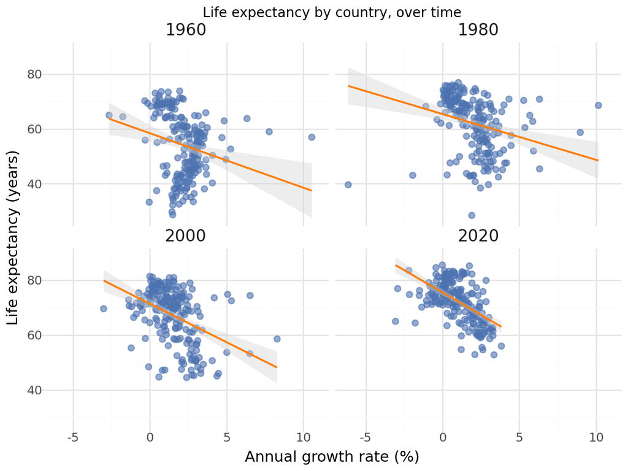

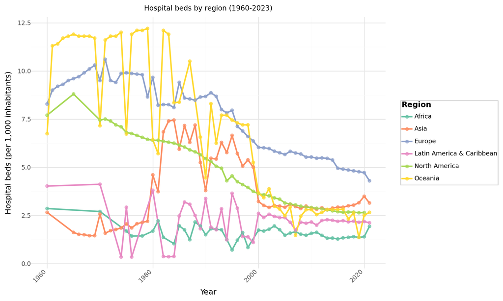

# What does the future hold for the world’s demographics?

As we enter the next few decades, **the demographic landscape is changing rapidly,** with some countries facing **rapid growth**, while others are confronted with **ageing and decline.**

This evolution has an **impact not only on economies and societies**, but also on the **environment: growth strains resources, while decline could enable more sustainable planning.**

For a broader perspective on how population growth shapes global development, check out this United Nations Policy Brief: [“Why population growth matters for sustainable development.”](https://www.un.org/development/desa/pd/sites/www.un.org.development.desa.pd/files/undesa_pd_2022_policy_brief_population_growth.pdf)